# Part II - Effect of user type on the number of bike rides

## by Imen Bakir

## Investigation Overview

There are two types of clients using this system: Subscribers and Customers. Subscribers are primarily daily commuters, having short trips to and from their destination which can be estimated as work or school, who rent a bike on weekdays at 8-9am and 5-6pm.

## Dataset Overview

This data set includes information about individual rides made in a bike-sharing system covering the greater San Francisco Bay area. There are approximately 183412 rides made in a bike-sharing system covering the greater "San Francisco Bay" area.

## Distribution of User Type

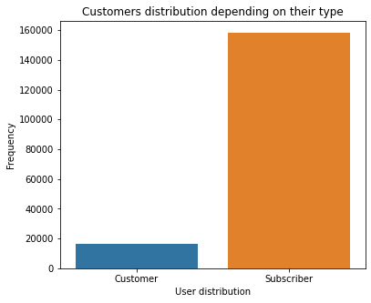

**Observation**

The majority of the users are subscribers and the lower type are Customers

## Bike rides' duration by user type

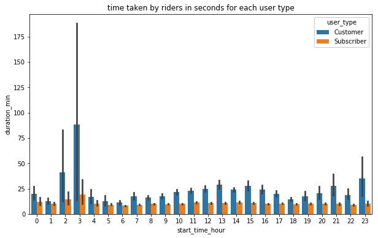

**Observation**

Subscribers tend to have longer bike rides at 2-3am. Also, their ride time is relatively constant throughout the day, which makes you think that Subscribers are primarily daily commuters, having short trips to and from their destination which can be estimated as work or school.

Meanwhile Customers have high bike-ride duration time than subscribers. And it peaks on 1:30-3am, 12-15pm and 23pm. Which makes you think that Customers are usually occassional riders who use the system mainly to explore the city.

## Bike daily rides by user type

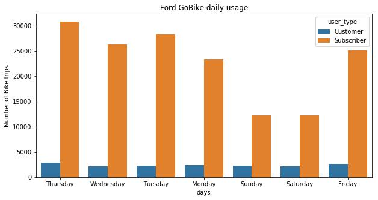

**Observation**

Customers take more bike trips usually on Thursdays.

Subscribers take bike rides more on working days : from Mondays to Fridays and tend to have less bike rides on Saturdays and Sundays. Which makes you conclude that Subscribers are primarily daily commuters, having short trips but more number of bike rides to and from their destination which can be estimated as work or school.